# Language of probability for machine learning : Markov Random Fields

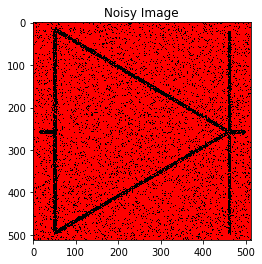

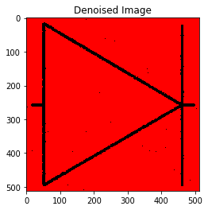

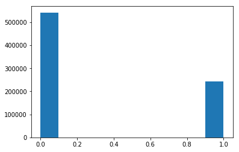

```python
plt.figure(7)
plt.imshow(Y)
plt.title("Noisy Image")
plt.figure(8)
plt.imshow(X)
plt.title("Denoised Image")
plt.figure(9)
plt.hist(X.flatten())
```

Another point is that $x_i$ can take more than 2 values i.e. -1, 1 so all cases of should be considered $x_i \in \{0, \cdots, 255\}$. The enumeration of all the cases is time consuming so we decide to enumerate values around $x_i$ such that $x_i-bound \leq x_i \leq x_i+bound$. Bound is a scalar that defines the neiborhood (the range). We should assign to $x_i$ the value that minimizes at best the energy.

```python
def MRF_ICM(X,Y,h,beta,eta,nbiter,bound):

    H,W,C = Y.shape
    xx=[]
    for ii in range(1,W-1):
        xx.append(ii)


    yy=[]
    for jj in range(1,H-1):
        yy.append(jj)

    np.random.shuffle(xx)
    np.random.shuffle(yy)

    it=0
    while it<nbiter:
        E=0
        for i in xx :
            for j in yy :

                listenergy=[]
                x_i=[0,0,0]
                low=int(max(X[i,j,0]-bound,0))
                high=int(min(X[i,j,0]+bound+1,256))
                for val in range(low,high):
                    x_i[0]=val

                    e1 = -h*np.linalg.norm(x_i,2)

                    x_down=X[i,j-1]
                    x_up=X[i,j+1]
                    x_left=X[i-1,j]
                    x_right=X[i+1,j]
                    e2 = np.linalg.norm(x_i-x_down,2) + np.linalg.norm(x_i-x_up,2)+np.linalg.norm(x_i-x_left,2)+np.linalg.norm(x_i-x_right,2)
                    e2=beta*e2

                    y_i=Y[i,j]
                    e3=eta*np.linalg.norm(x_i-y_i,2)

                    Ecur=e1+e2+e3
                    listenergy.append(Ecur)

                valmin=np.argmin(listenergy)
                X[i,j]=[valmin+low,0,0]
                E=E+listenergy[valmin]
        it=it+1
        plt.figure((it+10))
        print("Iteration=",it," Energy=", E)
        if it%5==0:
            plt.figure((it+10))
            plt.imshow(X[:,:,0],cmap='gray')
            plt.title("Iteration "+str(it))


    return X,E
```

Let's try this algorithm on our symbol image. For convenience (to use the np.linalg.norm function), the image whill have 3 channels but only the first one will carry information.

```
(512, 512, 3)
Iteration= 1  Energy= 86785.0
Iteration= 2  Energy= 37010.0
```

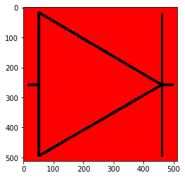

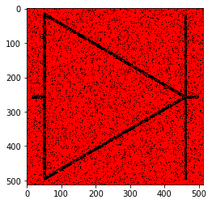

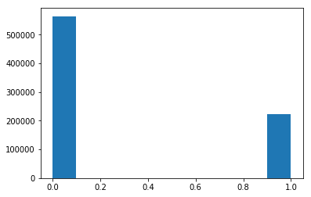

[figure not shown]

[figure not shown]

```python
Y=mpimg.imread("symbol031.png")
print(Y.shape)
Y[:,:,1]=0
Y[:,:,2]=0
plt.figure(6)
plt.imshow(Y)



noise = np.random.rand(Y.shape[0],Y.shape[1])
noise=noise<0.1
noise = 1-noise



Y[:,:,0]=Y[:,:,0]+noise

Y[Y[:,:,0]==2,0]=0
Y[:,:,0]=1-Y[:,:,0]

plt.figure(5)
plt.imshow(Y)

plt.figure(10)
plt.hist(Y.flatten())



h=0.0
beta=1.0
eta=1.0
nbiter=2
bound=1
X=Y.copy()

X,E=MRF_ICM(X,Y.copy(),h,beta,eta,nbiter,bound)
```

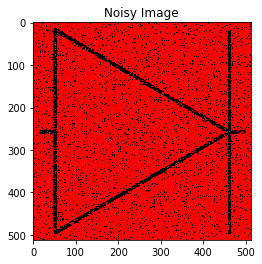

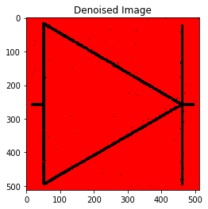

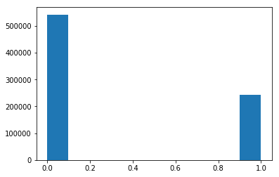

```python
plt.figure(7)
plt.imshow(Y)
plt.title("Noisy Image")
plt.figure(8)
plt.imshow(X)
plt.title("Denoised Image")
plt.figure(9)
plt.hist(X.flatten())
```

For convenience, the image whill have 3 channels but only the first one will carry information grey-level information.

```
(512, 512, 3)
144.0
Iteration= 1  Energy= 30149011.0
Iteration= 2  Energy= 29176116.0
Iteration= 3  Energy= 28234800.0
Iteration= 4  Energy= 27324855.0
Iteration= 5  Energy= 26445782.0
Iteration= 6  Energy= 25597060.0
Iteration= 7  Energy= 24778463.0
Iteration= 8  Energy= 23989463.0
Iteration= 9  Energy= 23229375.0
Iteration= 10  Energy= 22497935.0
Iteration= 11  Energy= 21794438.0
Iteration= 12  Energy= 21118159.0
Iteration= 13  Energy= 20468904.0
Iteration= 14  Energy= 19846512.0
Iteration= 15  Energy= 19250230.0
Iteration= 16  Energy= 18678990.0
```

```
Iteration= 17  Energy= 18132781.0
Iteration= 18  Energy= 17611200.0
Iteration= 19  Energy= 17113816.0
Iteration= 20  Energy= 16639540.0
Iteration= 21  Energy= 16187593.0
Iteration= 22  Energy= 15757772.0
Iteration= 23  Energy= 15349943.0
Iteration= 24  Energy= 14963617.0
Iteration= 25  Energy= 14597943.0
Iteration= 26  Energy= 14252164.0
Iteration= 27  Energy= 13925093.0
Iteration= 28  Energy= 13615863.0
Iteration= 29  Energy= 13324302.0
Iteration= 30  Energy= 13049889.0
Iteration= 31  Energy= 12792711.0
Iteration= 32  Energy= 12551372.0
Iteration= 33  Energy= 12325552.0
Iteration= 34  Energy= 12114654.0
Iteration= 35  Energy= 11917664.0
Iteration= 36  Energy= 11734330.0
Iteration= 37  Energy= 11563944.0
Iteration= 38  Energy= 11405897.0
Iteration= 39  Energy= 11259189.0
Iteration= 40  Energy= 11123619.0
Iteration= 41  Energy= 10998090.0
Iteration= 42  Energy= 10882459.0
Iteration= 43  Energy= 10776015.0
Iteration= 44  Energy= 10677968.0
Iteration= 45  Energy= 10588030.0
Iteration= 46  Energy= 10505847.0
Iteration= 47  Energy= 10430455.0
Iteration= 48  Energy= 10361581.0
Iteration= 49  Energy= 10298704.0
Iteration= 50  Energy= 10241483.0
Iteration= 51  Energy= 10189520.0
Iteration= 52  Energy= 10142435.0
Iteration= 53  Energy= 10099660.0
Iteration= 54  Energy= 10061015.0
Iteration= 55  Energy= 10025895.0
Iteration= 56  Energy= 9993915.0
```

[output cut: 9 more lines]

```
Iteration= 66  Energy= 9809500.0
Iteration= 67  Energy= 9799915.0
Iteration= 68  Energy= 9791324.0
Iteration= 69  Energy= 9783664.0
Iteration= 70  Energy= 9776723.0
Iteration= 71  Energy= 9770538.0
Iteration= 72  Energy= 9765039.0
Iteration= 73  Energy= 9760099.0
Iteration= 74  Energy= 9755697.0
Iteration= 75  Energy= 9751808.0
Iteration= 76  Energy= 9748372.0
Iteration= 77  Energy= 9745293.0
Iteration= 78  Energy= 9742549.0
Iteration= 79  Energy= 9740016.0
Iteration= 80  Energy= 9737766.0
```

[figure not shown]

[figure not shown]

[figure not shown]

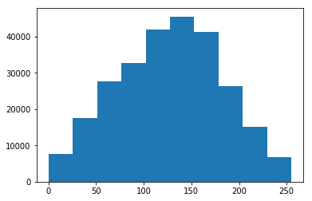

[figure not shown]

[figure not shown]

[figure not shown]

[figure not shown]

[figure not shown]

[figure not shown]

[figure not shown]

[figure not shown]

[7 more figures not shown]

```python
def rgb2gray(rgb):
    return np.dot(rgb[...,:3], [0.299, 0.587, 0.144])


img=mpimg.imread("lena.png")
gray = rgb2gray(img)
Y=img
print(Y.shape)
Y[:,:,0]=gray
Y[:,:,1]=0
Y[:,:,2]=0
plt.figure(6)
plt.imshow(Y[:,:,0],cmap='gray')



noise = np.random.normal(0.0,0.1,(Y.shape[0],Y.shape[1]))
#0.1*np.random.randn(Y.shape[0],Y.shape[1])
plt.figure(55)
plt.hist(noise.flatten())
Y[:,:,0]=Y[:,:,0]+noise
Y[Y[:,:,0]>1,0]=1
Y[Y[:,:,0]<0,0]=0


Y[:,:,0]=np.round(255*Y[:,:,0],0)
print(Y[0,0,0])
plt.figure(5)
plt.imshow(Y[:,:,0],cmap='gray')

plt.figure(10)
plt.hist(Y[:,:,0].flatten())


h=0.0
beta=1.0
eta=1.0
nbiter=80
X=Y.copy()

X,E=MRF_ICM(X,Y.copy(),h,beta,eta,nbiter)
```

[figure not shown]

[figure not shown]

[figure not shown]

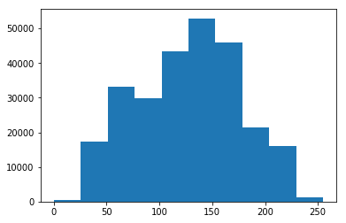

```python
img=mpimg.imread("lena.png")
gray = rgb2gray(img)
plt.figure(6)
plt.imshow(gray,cmap='gray')
plt.title("Noise Free Image")
plt.figure(7)
plt.imshow(Y[:,:,0],cmap='gray')
plt.title("Noisy Image")
plt.figure(8)
plt.imshow(X[:,:,0],cmap='gray')
plt.title("Denoised Image")
plt.figure(9)
plt.hist(X[:,:,0].flatten())
```